# Technical Olympic S.A. Stock Price Time Series Analysis

Themistocles Papavramidis

2024-09-20

## Introduction

This document presents a comprehensive time series analysis of Technical Olympic S.A. stock prices. The analysis includes:

- Time series decomposition
- Polynomial fitting for trend analysis
- Stationarity tests
- ARIMA modeling
- Forecasting future stock prices

We will begin by loading the necessary libraries and the dataset.

## Data Loading and Preprocessing

The dataset is loaded from a CSV file, and the date column is properly formatted.

```r
# Load the data
data <- read.csv('data.csv')
data$date <- as.Date(data$date, format = "%d/%m/%y")
data <- data.frame('date' = data$date, 'value' = data$value)
head(data)
```

```
##         date value
## 1 2020-01-04  0.39
## 2 2020-01-05  0.36
## 3 2020-01-07  0.38
## 4 2020-01-08  0.38
## 5 2020-01-11  0.36
## 6 2020-01-12  0.37
```

Next, we calculate the range of stock prices to be used later for plotting purposes.

```r
# Calculate the range of stock prices
r <- range(data$value)[2] - range(data$value)[1]
```

## Time Series Creation

We convert the stock values into a time series object with a frequency of 25 (representing approximately 25 trading days in a month) and visualize the time series.

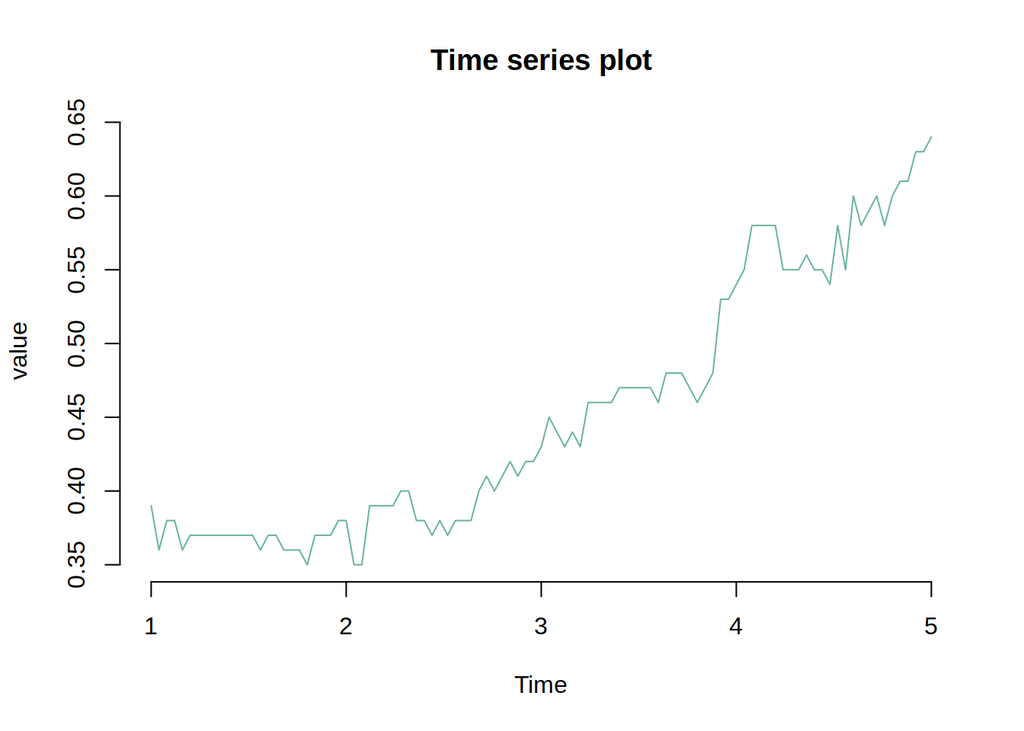

```r
# Create time series object
f <- 25  # Frequency
a <- 1   # Start of time series
value_ts <- ts(data$value, frequency = f, start = a)

# Plot the raw time series
plot.ts(value_ts, main="Time series plot", ylab='value', col='#69b3a2', bty='n')
```

## Time Series Decomposition

Now, we decompose the time series into trend, seasonality, and residual components. We also apply a Box-Cox transformation to stabilize the variance, and decompose the transformed series.

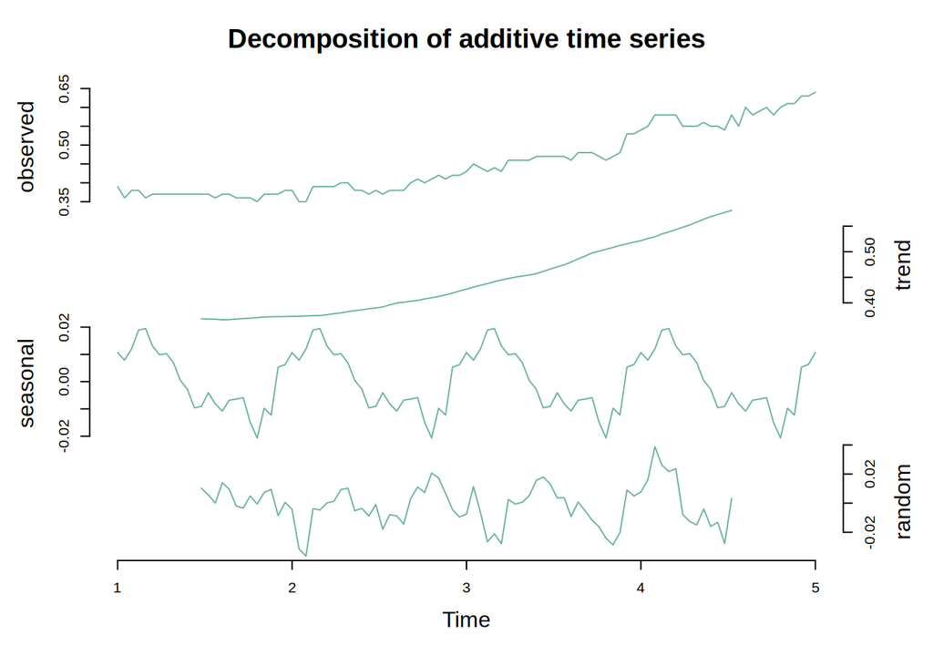

```r
# Decompose the original time series
par(mfrow=c(1,2))  # Set up for two plots side-by-side
value_dec <- decompose(value_ts)
plot(value_dec, yax.flip = TRUE, col='#69b3a2', bty='n')
```

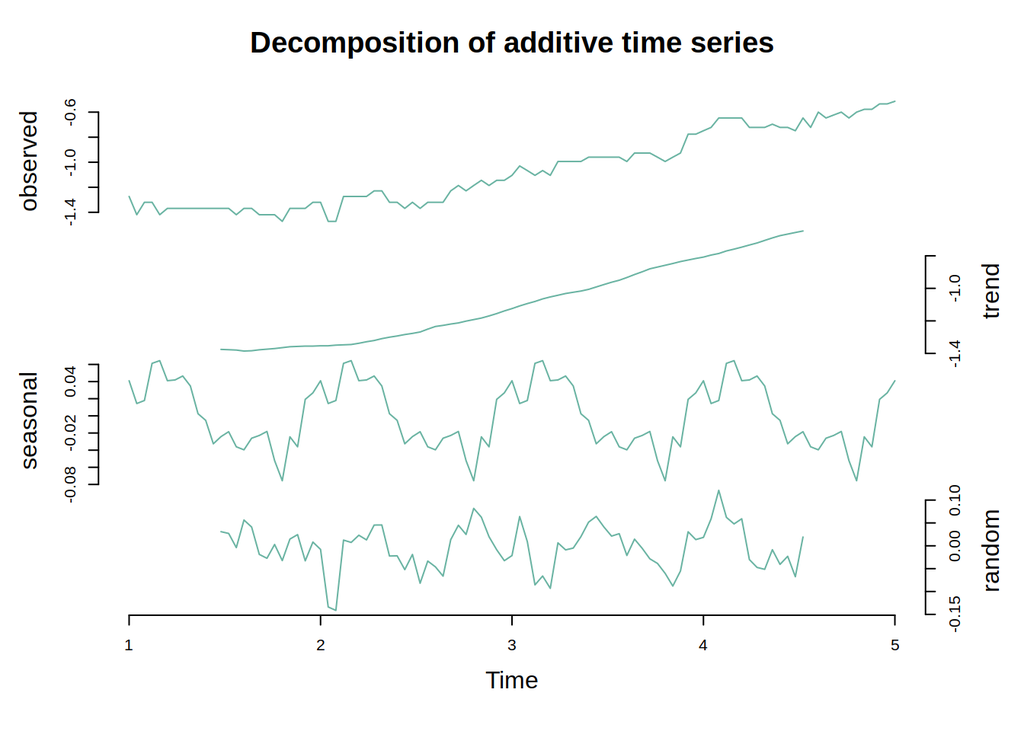

```r
# Apply Box-Cox transformation to stabilize variance
lambda <- BoxCox.lambda(value_ts)
log_ts <- BoxCox(value_ts, lambda)

# Decompose the transformed time series
value_dec_log <- decompose(log_ts)
plot(value_dec_log, yax.flip = TRUE, col='#69b3a2', bty='n')
```

## Polynomial Fitting

We fit polynomial models of different degrees to identify the best polynomial model for the data. We’ll examine the Adjusted R-squared, AIC, and BIC values for each model.

```
## [1] "Degree of polynomial:  1"
## [1] "Adjusted R squared:  0.881951949597329"
## [1] "AIC:  -420.461933175895"
## [1] "BIC:  -412.616571625371"
```

```
## [1] "Degree of polynomial:  2"
## [1] "Adjusted R squared:  0.960069182912771"
## [1] "AIC:  -528.965602510792"
## [1] "BIC:  -518.505120443427"
```

```
## [1] "Degree of polynomial:  3"
## [1] "Adjusted R squared:  0.965058884548141"
## [1] "AIC:  -541.483408670466"
## [1] "BIC:  -528.407806086259"
```

```
## [1] "Degree of polynomial:  4"
## [1] "Adjusted R squared:  0.964833905318662"
## [1] "AIC:  -539.881814975658"
## [1] "BIC:  -524.19109187461"
```

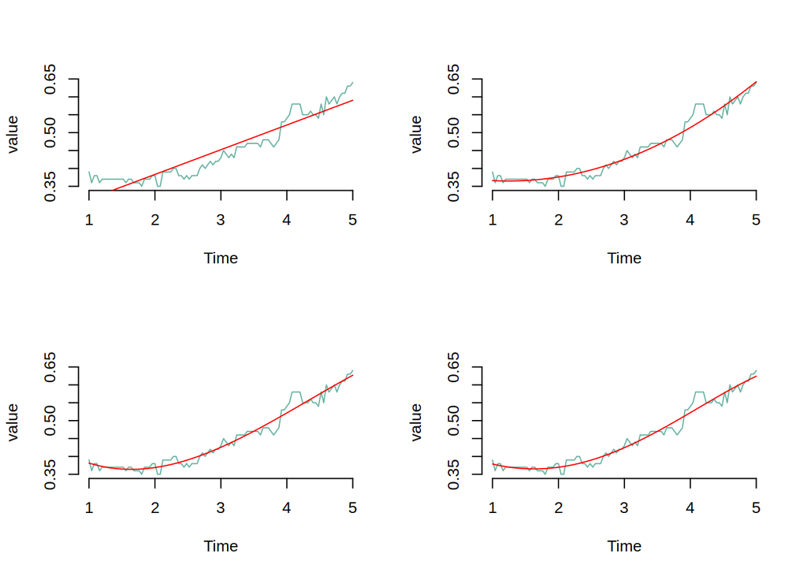

```r
# Polynomial fitting for degrees 1 to 4
n <- 4  # Maximum degree of polynomial
t <- 1:length(value_ts)

par(mfrow=c(2,2))  # Set up for 2x2 grid of plots

for (i in 1:n) {
  # Fit polynomial model
  fit_poln <- lm(value_ts ~ poly(t, i))

  # Print performance metrics
  print(paste('Degree of polynomial: ', i))
  print(paste('Adjusted R squared: ', summary(fit_poln)$adj.r.squared))
  print(paste('AIC: ', AIC(fit_poln)))
  print(paste('BIC: ', BIC(fit_poln)))

  # Plot observed vs fitted values
  plot(value_ts, ylab='value', col='#69b3a2', bty='n')
  lines(ts(fit_poln$fitted.values, frequency = f, start = a), col='red')
}
```

Based on the analysis, we choose the polynomial model with degree 3 and analyze the residuals.

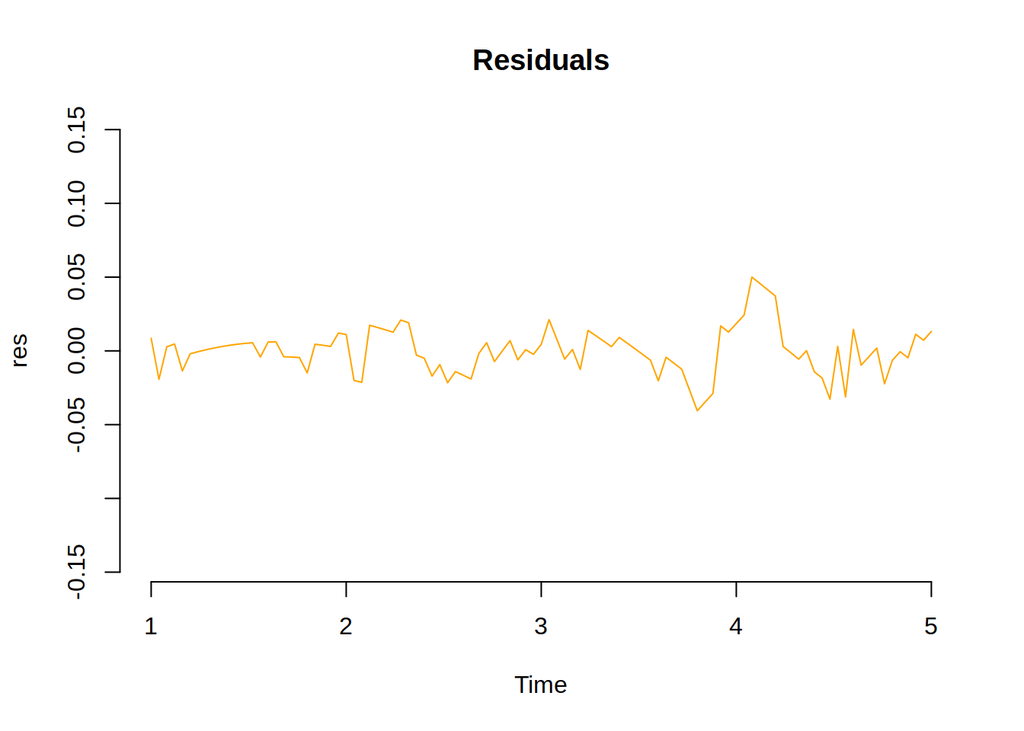

```r
# Fit degree 3 polynomial model
fit_poln <- lm(value_ts ~ poly(t, 3))

# Calculate residuals
value_pol <- ts(value_ts - fit_poln$fitted.values, frequency = f, start = a)

# Plot the residuals
plot.ts(value_pol, col='orange', main='Residuals', ylab='res', bty='n', ylim=c(-r/2, r/2))
```

## Stationarity Tests

To ensure stationarity, we perform both the Augmented Dickey-Fuller (ADF) and KPSS tests on the time series.

```r
# Perform ADF test for stationarity
adf_result <- adf.test(value_ts)
print(adf_result)
```

```
##
##  Augmented Dickey-Fuller Test
##
## data:  value_ts
## Dickey-Fuller = -1.9222, Lag order = 4, p-value = 0.6089
## alternative hypothesis: stationary
```

```r
# Perform KPSS test for stationarity
kpss_result <- kpss.test(value_ts)
print(kpss_result)
```

```
##
##  KPSS Test for Level Stationarity
##
## data:  value_ts
## KPSS Level = 1.9715, Truncation lag parameter = 4, p-value = 0.01
```

## Differencing the Series

To remove trend and seasonality, we apply differencing to the series.

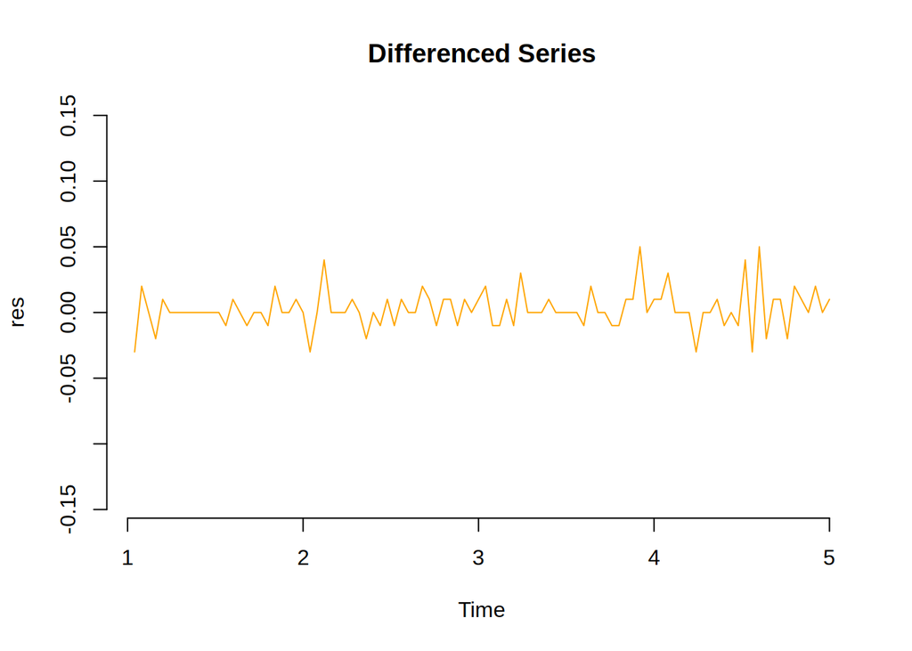

```r
# Differencing to eliminate trend and seasonality
l <- 1  # Lag
d <- ndiffs(value_ts, test = "adf")  # Determine number of differences

# Apply differencing
value_dif <- diff(value_ts, lag = l, differences = d)

# Plot the differenced series
plot.ts(value_dif, main='Differenced Series', ylab='res', col='orange', ylim=c(-r/2, r/2), bty='n')
```

## ACF and PACF

We use the ACF and PACF plots to determine the AR and MA terms for the ARIMA model.

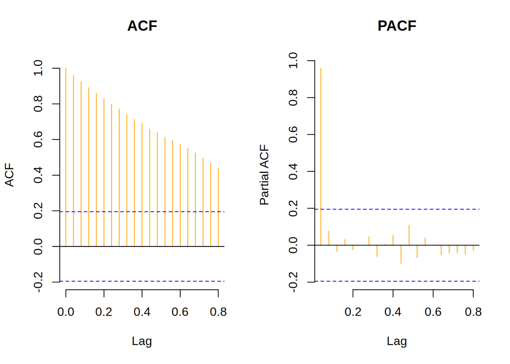

```r
# Plot ACF and PACF to identify ARIMA parameters
par(mfrow=c(1,2))
acf(value_ts, main = 'ACF', col='orange', bty='n')
pacf(value_ts, main = 'PACF', col='orange', bty='n')
```

## ARIMA Modeling

Based on the ACF/PACF plots, we fit AR, MA, and ARIMA models and plot the fitted values and residuals for each.

### AR(1) Model

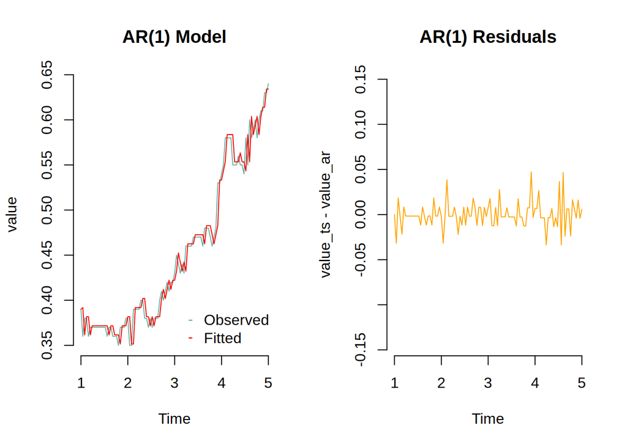

```r
# Fit AR(1) model
fit_ar <- arima(value_ts, order = c(1, 0, 0), method = 'CSS')
value_ar <- fitted(fit_ar)

# Plot fitted AR(1) values
par(mfrow=c(1,2))
plot.ts(value_ts, ylab='value', main='AR(1) Model', col='#69b3a2', bty='n')
lines(value_ar, col='red')
legend('bottomright', legend=c('Observed', 'Fitted'), col=c('#69b3a2', 'red'), pch=c('-', '-'), bty='n')

# Plot residuals of AR(1) model
plot.ts(value_ts - value_ar, col='orange', main='AR(1) Residuals', ylim=c(-r/2, r/2), bty='n')
```

### MA(11) Model

```r
# Fit MA(11) model
fit_ma <- arima(value_ts, order = c(0, 0, 11), method = 'CSS')
```

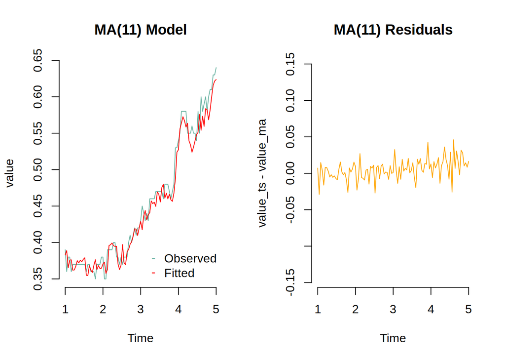

```r
value_ma <- fitted(fit_ma)

# Plot fitted MA(11) values
par(mfrow=c(1,2))
plot.ts(value_ts, ylab='value', main='MA(11) Model', col='#69b3a2', bty='n')
lines(value_ma, col='red')
legend('bottomright', legend=c('Observed', 'Fitted'), col=c('#69b3a2', 'red'), pch=c('-', '-'), bty='n')

# Plot residuals of MA(11) model
plot.ts(value_ts - value_ma, col='orange', main='MA(11) Residuals', ylim=c(-r/2, r/2), bty='n')
```

### ARIMA(1,1,11) Model

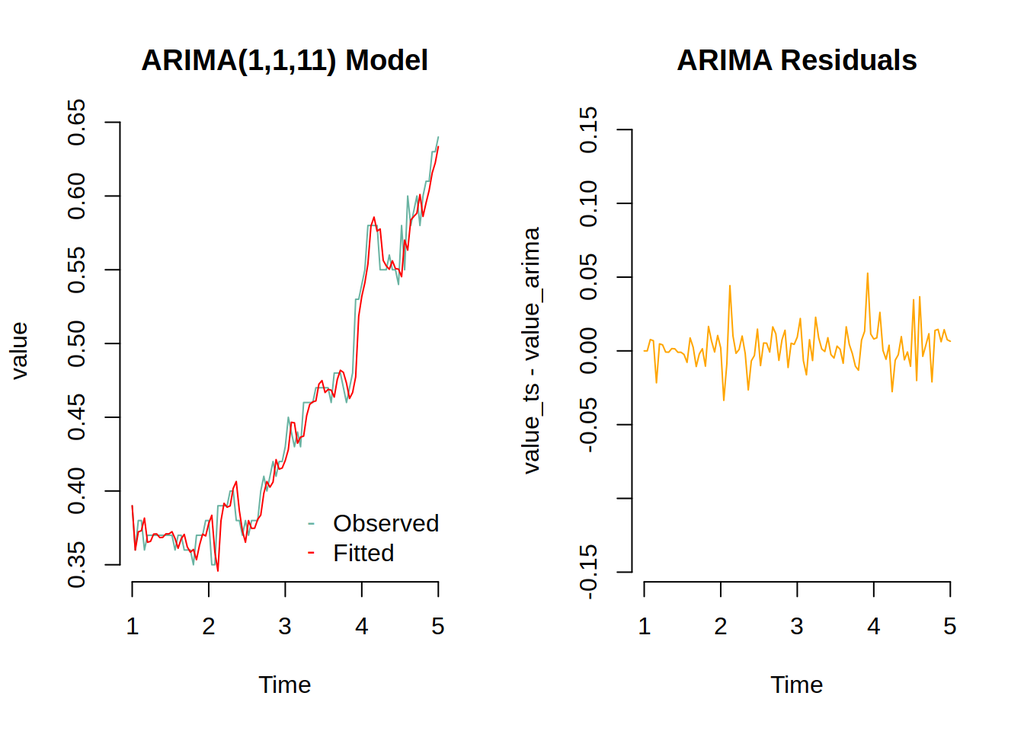

```r
# Fit ARIMA(1,1,11) model
fit_arima <- arima(value_ts, order = c(1, d, 11), method = 'CSS')
value_arima <- fitted(fit_arima)

# Plot fitted ARIMA values
par(mfrow=c(1,2))
plot.ts(value_ts, ylab='value', main='ARIMA(1,1,11) Model', col='#69b3a2', bty='n')
lines(value_arima, col='red')
legend('bottomright', legend=c('Observed', 'Fitted'), col=c('#69b3a2', 'red'), pch=c('-', '-'), bty='n')

# Plot residuals of ARIMA model
plot.ts(value_ts - value_arima, col='orange', main='ARIMA Residuals', ylim=c(-r/2, r/2), bty='n')
```

## Model Diagnostics

We perform residual diagnostic checks on the ARIMA model to ensure the residuals are uncorrelated.

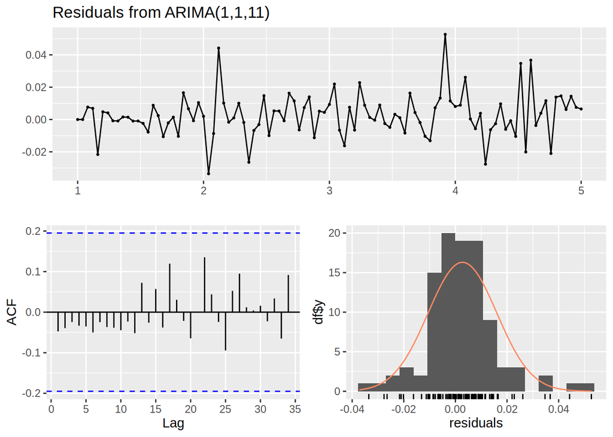

```
##
##  Ljung-Box test
##
## data:  Residuals from ARIMA(1,1,11)
## Q* = 5.7138, df = 8, p-value = 0.6793
##
## Model df: 12.   Total lags used: 20
```

```r
# Perform diagnostic checks on ARIMA residuals
checkresiduals(fit_arima)
```

## Forecasting

```r
# Forecast future stock prices
frcast <- forecast(fit_arima, h = 7)

# Display the forecasted values
kable(frcast)
```

|  | Point Forecast | Lo 80 | Hi 80 | Lo 95 | Hi 95 |
| --- | --- | --- | --- | --- | --- |
| 5.04 | 0.6429749 | 0.6254552 | 0.6604945 | 0.6161809 | 0.6697688 |
| 5.08 | 0.6434845 | 0.6214674 | 0.6655017 | 0.6098122 | 0.6771568 |
| 5.12 | 0.6470632 | 0.6197958 | 0.6743305 | 0.6053614 | 0.6887650 |
| 5.16 | 0.6443017 | 0.6128249 | 0.6757784 | 0.5961621 | 0.6924412 |
| 5.20 | 0.6436939 | 0.6082746 | 0.6791132 | 0.5895248 | 0.6978630 |
| 5.24 | 0.6450967 | 0.6056249 | 0.6845685 | 0.5847298 | 0.7054636 |
| 5.28 | 0.6442563 | 0.6008445 | 0.6876681 | 0.5778637 | 0.7106489 |

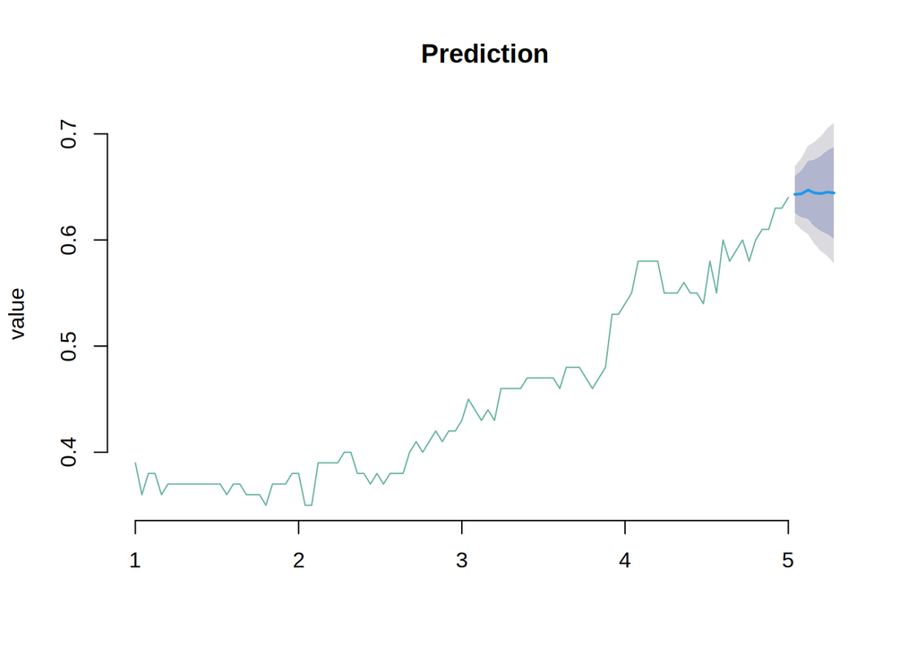

```r
# Plot the forecast
plot(frcast, main = "Prediction", ylab = 'value', col = '#69b3a2', bty = 'n')
```

## Accuracy of the Forecast

We evaluate the accuracy of the fitted ARIMA model by comparing the fitted values to the actual stock prices.

```r
# Assess accuracy of the fitted ARIMA model
kable(accuracy(frcast$fitted, data$value))
```

|  | ME | RMSE | MAE | MPE | MAPE |
| --- | --- | --- | --- | --- | --- |
| Test set | 0.002737 | 0.0135346 | 0.0095709 | 0.5086794 | 2.107685 |